# Introduction to Neural Networks with PyTorch

Author: Josue N Rivera

### Outline

- Setup
- Main Components
  - Neural Networks Architecture
    - Multi-Layers Perceptron
      - Linear Layers (a.k.a. fully connected layers)
      - Nonlinear Activation Layers
      - Loss function
    - Convolutional Neural Networks (brief introduction)
  - Gradients Calculation with Backpropagation
  - Parameters Optimization
    - Gradient Descent
    - Stochastic Gradient Descent
- Contributions

### Setup

In practice, the following dependencies are not needed for this tutorial if you have intermediate skills with computer programming. However, to reduce the complexity of this tutorial and take advantages of the speed-up provided by parallelization and the GPU, we will rely on the following tools. To learn how to code it without any of the following dependencies, you can follow this [video tutorial](https://www.youtube.com/watch?v=hfMk-kjRv4c).

- **PyTorch** (For creating tensors of various sizes, calculating gradient via backpropagation and performing parameters' optimization)
- **Matplotlib** (Plotting tool)
- **pandas** (Holding data for plotting)

[Optional] Start by installing [Anaconda](https://www.anaconda.com/products/distribution) or [miniconda](https://docs.conda.io/en/latest/miniconda.html#latest-miniconda-installer-links) to create python environment. Otherwise, use `www.pytorch.org` to download PyTorch and only execute the last command below.

```python
# Create conda enviorment (optional)
conda create --name pydemo python=3.8
conda activate pydemo

# Pytorch - Option 1: CPU version (preferred: use `www.pytorch.org` to choose the best PyTorch version for you)
conda install pytorch cpuonly -c pytorch

# Pytorch - Option 2: Nvidia GPU version (preferred: use `www.pytorch.org` to choose the best PyTorch version for you)
conda install pytorch cudatoolkit=11.6 -c pytorch -c conda-forge

pip install matplotlib pandas
```

```python
# import installed libraries
import torch as th
import torch.nn as nn
import matplotlib.pyplot as plt
import pandas as pd
```

#### Setup: *Random Dataset*

The following code is to generate an random dataset with 2 inputs and 1 label for demonstrations

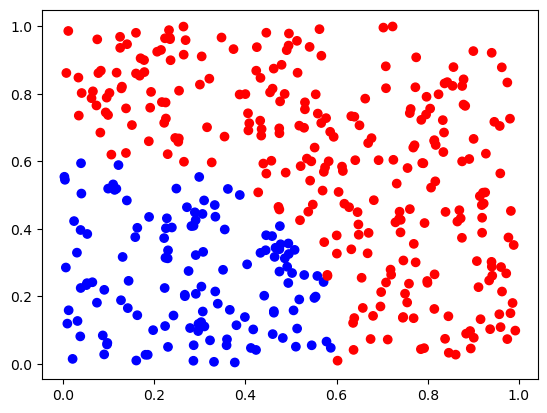

```python
ndata = 400
layer_n = [2, 3, 3, 1]

## data generation
X = th.rand(ndata, layer_n[0])
Y = 1.0*(th.linalg.norm(X-th.tensor([0.1, 0.1]), dim=1) > 0.5)
X_grid, Y_grid = th.meshgrid(
                th.linspace(0, 1, steps=100),
                th.linspace(0, 1, steps=100), indexing='ij')
grid_in = th.stack((X_grid, Y_grid), 2).view(-1, 2)

## store data for plotting
dtpd = pd.DataFrame(X, columns=['$x_1$', '$x_2$'])
dtpd['y'] = Y
Y = Y.unsqueeze(dim=-1)
dtpd['label_color'] = dtpd['y'].apply(lambda y: "red" if y==1 else "blue")

## plotting
plt.scatter(data=dtpd, x='$x_1$', y='$x_2$', c=dtpd['label_color'])
plt.show()
```

```python
# Training and plotting functions

def train(net, opt, criterion, epochs=10000, train_size=-1, batch_size=-1):
    losses = []

    # gradient decent
    for epoch in range(epochs):  # loop over the dataset multiple times

        # zero the parameter gradients
        opt.zero_grad()

        # forward + backward + optimize
        outputs = net(X[:train_size])
        loss = criterion(outputs, Y[:train_size])
        loss.backward()
        opt.step()

        # log loss
        losses.append(loss.item())

    return losses

def get_heatmap(net):
    heat = net(grid_in).view(100, 100)
    pred = net(X)
    return heat, pred

def plot_boundary_loss(fig, heat, losses, title="Test"):
    heat[heat > 0.51] = 1.0
    heat[heat < 0.49] = 0.0
    heat = heat.cpu().detach().numpy()

    subfgs = fig.subfigures(1, 2)
    ax1 = subfgs[0].subplots(1, 1)
    ax2 = subfgs[1].subplots(1, 1)

    ax1.imshow(heat, cmap='bwr', interpolation='bicubic', alpha=0.4, origin='lower')
    ax1.set_title('Boundary line')
    ax1.scatter(dtpd['$x_1$']*99, dtpd['$x_2$']*99, c=dtpd['label_color'])
    ax1.set_xlim([0, 99])
    ax1.set_ylim([0, 99])

    ax2.set_title('Loss over Epochs')
    ax2.plot(losses)
    ax2.set_xlabel('epoch')
    ax2.set_ylabel('MSE')
    ax2.grid()

    fig.suptitle(title, fontsize=16)
```

### Neural Networks Architecture

Let $\hat{X}$ represent an input domain, $\hat{Y}$ represent an output codomain and $\hat{f}: \hat{X} \rightarrow \hat{Y}$ an unknown function that maps values from the set $\hat{X}$ to $\hat{Y}$. Given subsets $X \subseteq \hat{X}$ and $Y \subseteq \hat{Y}$, can we build a function $f$ that equals $\hat{f}$?

Recent works on *Universal Approximation Theorem* establishes the capabilities of artificial neural networks (in particular multi-layer perceptrons) to approximate the mapping between two euclidean spaces given a big enough error of margin $\epsilon > 0$ and number of neurons satisfying, $$ \int_{\hat{X}}\|f(x)-\hat{f}(x)\|dx < \epsilon $$ There are some works discussing the approximation capabilities of neural networks for mapping to and/or from non-euclidean spaces, but the work is ongoing. For further reading, seen the references below.

[figure not shown]

Different neural networks architectures also approximate different subspaces of functions. For the sake of visualization, we can perceive $H_0$ as a hypothetical subspace of functions that can be approximated by a multi-layer perceptrons, $H_1$ as subspace of functions that can be approximated by convolutional neural networks and the rest as other subspaces approximated by certain neural network architectures. Multi-layer perceptrons and convolutional neural networks will be explored in the following sections. Given a task $T$ (e.g. $T_1$, $T_2$), there is a set of functions ($F_1$ and $F_2$, respectively) such that an element in the set $f(x)$ will be meet the condition $\int_{\hat{X}}\|f(x)-\hat{f}(x)\|dx < \epsilon$. Thus, the goal with the optimization of a neural network is to find a function in the subset ($f(x) \in F$). The smaller the subset $H$ is for a given architecture while encompassing the set of functions for a given task $T$, the smaller the search space for a function $f(x) \in F$ will be.

*Reference:*

- [Universal Approximation Theorem](https://en.wikipedia.org/wiki/Universal_approximation_theorem) (Wikipedia)
- [A Universal Approximation Theorem of Deep Neural Networks for Expressing Probability Distributions](https://proceedings.neurips.cc/paper/2020/hash/2000f6325dfc4fc3201fc45ed01c7a5d-Abstract.html), Lu, Yulong 2020
- [Neural network approximation](https://www.cambridge.org/core/services/aop-cambridge-core/content/view/7077A90FB36D405D903DCC82683B7A48/S0962492921000052a.pdf/neural-network-approximation.pdf), DeVore 2021
- [Deep Neural Network Approximation Theory](https://ieeexplore.ieee.org/stamp/stamp.jsp?tp=&arnumber=9363169), Elbrächter 2021

### Neural Networks Architecture: *Multi-Layer Perceptron (MLP)*

Multilayer perceptron (a.k.a. fully-connected neural networks) are a sequence of repeating linear transformations followed by non-linear transformation for which the linear transform matrix $W_i$ are learnable parameters.

[figure not shown]

For example, the 3-layers MLP illustrated above can be described by the following sequence of transformations for a single input:

$$ z_1= W_1 x + b_1\\ a_1=\sigma(z_1)\\ z_2= W_2 a_1 + b_2\\ a_2=\sigma(z_2)\\ z_3= W_3 a_2 + b_3\\ h=\sigma(z_3) $$

Which can be also represented by the following equations for batched inputs:

$$\bar{z}_1= \bar{x}\bar{W_1}^{T}\\ \bar{a}_1=\sigma(\bar{z}_1)\\ \bar{z}_2= \bar{a}_1\bar{W_2}^{T}\\ \bar{a}_2=\sigma(\bar{z}_2)\\ \bar{z}_3= \bar{a}_2\bar{W_3}^{T}\\ \bar{h}=\sigma(\bar{z}_3)$$

Where , $\sigma$ is a non-linear function (e.g. sigmoid function, ReLu, etc.) and

$$\bar{x} = \begin{bmatrix} x_{b1}^T & 1\\ x_{b2}^T & 1\\ \vdots & \vdots \\ x_{bk}^T & 1\end{bmatrix}, \bar{W_i} = \begin{bmatrix} W_i & b_i\end{bmatrix}$$

such that $\bar{W}_i \in R^{n\times (m+1)}$ are learnable parameters, $x_{bi}\in \hat{X} \subseteq R^m$, $n$ is the size of the output vector and $m$ is the size of the input vector and k is the size of input batch. Note that due to [PyTorch broadcast](https://pytorch.org/docs/stable/notes/broadcasting.html), a conventional neural network or MLP does not have to be rewritten in the batched format for batched inputs. Often, it is sufficient to just describe the input $x$ as sequence of vectors, transpose the original matrix and change the order of operation for the matrix multiplication.

$$ \tilde{x} = \begin{bmatrix} x_{b1}^T\\ x_{b2}^T\\ \vdots \\ x_{bk}^T\end{bmatrix}, \tilde{W_i} = W_i^T, z = \tilde{x}\tilde{W} + b$$

### A MLP without Non-Linear Activation Layers

Let $x_i \in X \subseteq \hat{X} = \{x: 0 \leq x \leq 1, x \in R^2 \}$, $y_i \in Y \subseteq \hat{Y} = \{0, 1\}$ and $\hat{f}: \hat{X} \rightarrow \hat{Y}$ an unknown function. Then, let $f_{MLP}(x)$ be a neural network that approximates $\hat{f}$ defined as,

$$f_{MLP}(x) = \sigma(\bar{x}\bar{W_1}^{T}\bar{W_2}^{T}\bar{W_3}^{T}) = \sigma(\bar{x}\bar{W}_{1,2,3}^{T})$$

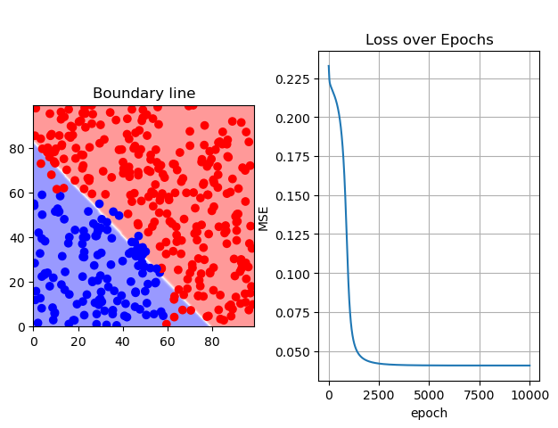

```python
## MLP without non-linear activation layers

# Construct model
layers = []
for i in range(len(layer_n)-1):
    layers.append(nn.Linear(layer_n[i], layer_n[i+1]))

model = nn.Sequential(*layers)
criterion = nn.MSELoss()
optimizer = th.optim.SGD(model.parameters(), lr=0.01, momentum=0.9)

# Calculate Gradient and Optimize
losses = train(model, optimizer, criterion)

# Plot boundary line and loss
heat, pred = get_heatmap(model)
fig = plt.figure()
plot_boundary_loss(fig, heat, losses, title="MLP without non-linear functions")
plt.show()
```

### Non-Linear Activation Layers

As seen in the MLP consisting of just linear activation, a neural network with just linear transformation is not able to create non-linear boundary lines that may separate a given dataset optimally. Thus, we must include non-linear functions to create non-linear boundary lines.

Let $f_{MLP}(x)$ be a neural network that approximates $\hat{f}$ defined as,

$$f_{MLP}(x) = \sigma(\sigma(\sigma(\bar{x}\bar{W_1}^{T})\bar{W_2}^{T})\bar{W_3}^{T})$$

$$\sigma(x) = \frac{1}{1+e^{-x}} \text{ (sigmoid function)}$$

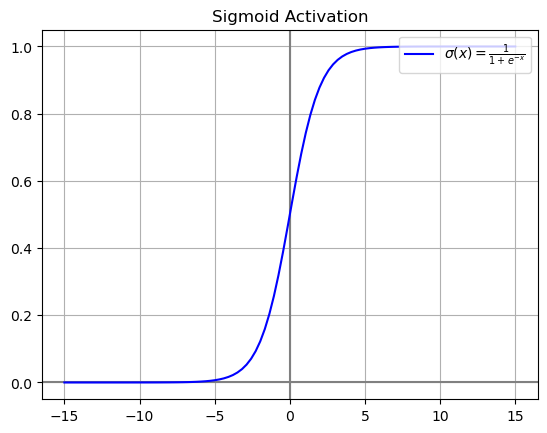

```python
xline = th.linspace(-15, 15, steps=100)
plt.axhline(0, color='grey')
plt.axvline(0, color='grey')
plt.plot(xline, 1/(1+th.exp(-xline)), label="$\sigma(x)=\\frac{1}{1+e^{-x}}$", c='blue')
plt.title("Sigmoid Activation")
plt.legend(loc=1)
plt.grid()
plt.show()
```

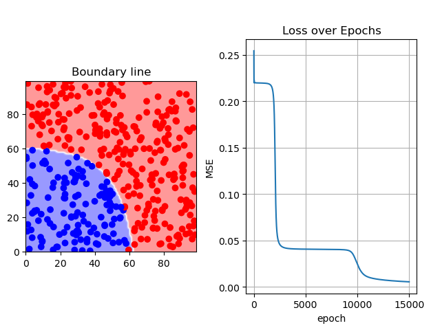

```python
## MLP with sigmoid function

# Construct model
layers = []
for i in range(len(layer_n)-1):
    layers.append(nn.Linear(layer_n[i], layer_n[i+1]))
    layers.append(nn.Sigmoid())

model = nn.Sequential(*layers)
criterion = nn.MSELoss()
optimizer = th.optim.SGD(model.parameters(), lr=0.1, momentum=0.9)

# Calculate Gradient and Optimize
losses = train(model, optimizer, criterion, epochs=15000)

# Plot boundary line and loss
heat, pred = get_heatmap(model)
fig = plt.figure()
plot_boundary_loss(fig, heat, losses, title="MLP with Sigmoid functions")
plt.show()
```

Now, for all hidden layers (that is all layers except for the output layer or all layers extracting features from input), let's define,

$$\sigma(x) = \max (0, x) \text{ (ReLu function)}$$

For all hidden layers.

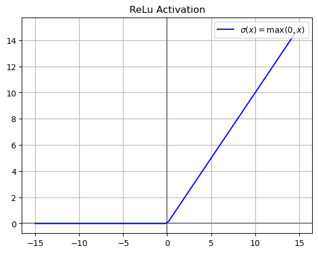

```python
xline = th.linspace(-15, 15, steps=100)
plt.axhline(0, color='grey')
plt.axvline(0, color='grey')
plt.plot(xline, th.relu(xline), label="$\sigma(x)=\\max(0, x)$", c='blue')
plt.legend(loc=1)
plt.title("ReLu Activation")
plt.grid()
plt.show()
```

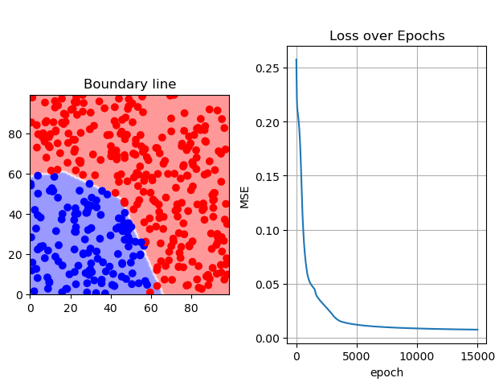

```python
## MLP with Relu function

# Construct model
layers = [nn.Linear(layer_n[0], layer_n[1])]
for i in range(1,len(layer_n)-1):
    layers.append(nn.ReLU())
    layers.append(nn.Linear(layer_n[i], layer_n[i+1]))
layers.append(nn.Sigmoid())

model = nn.Sequential(*layers)
criterion = nn.MSELoss()
optimizer = th.optim.SGD(model.parameters(), lr=0.01, momentum=0.9)

# Calculate Gradient and Optimize
losses = train(model, optimizer, criterion, epochs=15000)

# Plot boundary line and loss
heat, pred = get_heatmap(model)
fig = plt.figure()
plot_boundary_loss(fig, heat, losses, title="MLP with ReLu functions")
plt.show()
```

### Loss Function

As aforementioned, the goal with a neural network is to define a function $f(x)$ such that

$$\int_{\hat{X}}\|f(x)-\hat{f}(x)\|dx < \epsilon$$

holds for the smallest $\epsilon > 0$ possible. As such, we must optimize our neural network so that $\hat{f}_{obj}(\hat{X}) = \int_{\hat{X}}\|f(x)-\hat{f}(x)\|dx$ is as small as possible. However, in some cases optimizing for $\hat{f}_{obj}(\hat{X})$ directly may at times take a significant amount of time and resources or is infeasible (e.g. $Y = \emptyset$, $X \neq \hat{X}$, $Y \neq \hat{Y}$, etc.). As such, researchers have proposed various objective function alternatives $f_{obj}(X)$ (known as loss functions) based on the information known for unknown function $\hat{f}(x)$. Common loss functions include:

1. **MAE, MSE, etc.** $$f_{obj}(X,Y) = \sum^{N}_i \frac{ \| f(x_i)- y_i \|}{N} $$
2. **MBE** $$f_{obj}(X,Y) = \sum^{N}_i \frac{ f(x_i)- y_i}{N}$$
3. **Cross Entropy Loss/Negative Log Likelihood** $$f_{obj}(X,Y) = -\sum^{N}_i [f(x_i) log(y_i) + (1-f(x_i)) log(1 - y_i)]$$
4. **Heat PDE Residual** $$f_{obj}(X) = \sum^{N}_i \frac{\left \| \frac{\partial f}{\partial \bar{x}_t} - c^2 \frac{\partial f}{\partial \bar{x}_x} \bigg\rvert_{\bar{x}=x_i} \right \| }{N} $$

### Neural Networks Architecture: *Convolutional Neural Network (CNN)*

Although it is not appropriate for the classification task at hand, there is another popular neural network architecture that we should reference. That is the convolutional neural network. It relies on the convolution operation which is defined as,

$$(f \ast g)(t):=\int_{t_0}^{t_f} f(t-\tau) g(\tau) d \tau$$

is the continuous domain, and, more appropriate for us, as,

$$(f \ast g)[n]:= \sum_{k=k_0}^{k_f} f[n-k] g[k]$$

in the discrete domain where [$t_0$, $t_f$] and [$k_0$, $k_f$] is the support of $g(t)$ and $g[k]$, respectively, and $f(t)$ and $f[k]$ are expected to have a larger than or equal to support as $g(t)$ and $g[k]$, respectively. Note that certain transformations, like Fourier and Laplace transforms, have special properties for a [convolution](https://en.wikipedia.org/wiki/Convolution) which will not be discussed in this tutorial. Visualizations of 1D and 2D convolutions are presented below, respectively.

```
1D Convolution
```

[figure not shown]

```
2D Convolution
```

[figure not shown]

Now, the idea with CNN is to make $g$ a discretized tensor $\tilde{g}$ that is a learnable parameter like $W$ (aforementioned during MLP discussion). Then, inserting the convolution operation into an existing neural network structure. For example, an typical CNN would look something like,

$$z_1 = (\tilde{f} \ast \tilde{g})[\tilde{X}]\\ a_1 = \sigma(z_1)\\ z_2 = (\tilde{f} \ast \tilde{g})[a_1]\\ a_2 = \sigma(z_2)\\ a^*_2 = vector(a_2)\\ h = f_{MLP}(a^*_2)$$

Where $(\tilde{f} \ast \tilde{g})[\tilde{X}]$ is the convolution operation of every element of the discretized input $\tilde{f}$ in the domain $\tilde{X}$ (think of an image), $f_{MLP}(x)$ is an MLP as described before, and $vector(a)$ is the operation of flattening the input tensor $a \in R^{n \times \dots \times n}$ into a vector $\hat{a} \in R^{n^k}$ where k is the number of dimensions of $a$.

### Gradients Calculation with Backpropagation

Although it is not necessary to optimize the parameters of a neural network (such as when using evolution-based optimization method), many optimization schemes use gradients to train neural networks. As such, the backpropagation algorithm was developed to automatically compute the gradients of operations in the neural network and loss function with respect to various variables and parameters. In particular, most optimization scheme rely on the calculation of the gradient of the loss with respect to the learnable parameters followed by an update to the model for the next training iteration. It relies on the chain rule of calculus to avoid recomputing gradients, and solves for the gradients analytically by tracking the operations performed and storing the known gradient formulation. To explore backpropagation, we will use PyTorch autograd tool and look at the following example.

Given $x_i \in X \subseteq \hat{X}$ and $y_i \in Y \subseteq \hat{Y}$, let's define a generic neural network and a generic associated loss function,

$$f_{MLP}(x)=\sigma(W_2 \sigma(W_1 x + b_1) + b_2)$$$$f_{obj}(x_i,y_i) = (f_{MLP}(x_i)- y_i)^2 $$

These set of operations can be further discomposed into sequence of simpler operations,

$$ z_1= W_1 x_i + b_1\\ a_1=\sigma(z_1)\\ z_2= W_2 a_1 + b_2\\ h=\sigma(z_2)\\ L = (h - y_i)^2 $$

Now, the goal with this backpropagation algorithm is to calculate the gradient of the loss function $L$ with respect to each of the learnable parameter by starting with the loss and calculating the gradient backwards from the loss to each parameter. For example, to calculate the gradient $\frac{\partial L}{\partial W_1}$ and $\frac{\partial L}{\partial b_2}$, we can discompose them using the chain rule the following ways,

$$\frac{\partial L}{\partial W_1} = \left [ \frac{\partial L}{\partial h} \frac{\partial h}{\partial z_2} \right ] \frac{\partial z_2}{\partial a_1} \frac{\partial a_1}{\partial z_1} \frac{\partial z_1}{\partial W_1}$$$$\frac{\partial L}{\partial b_2} = \left [ \frac{\partial L}{\partial h} \frac{\partial h}{\partial z_2} \right ] \frac{\partial z_2}{\partial b_2}$$

As seen, we can take advantage of the fact that many partial derivatives (example highlighted inside the brackets $[ ]$) of the gradients of the loss are shared and thus, for a given input, one can store these partial derivatives and reuse them. We can also observe that to calculate the gradients of loss $L$ with respect to an earlier learnable parameter in the order of operations, we must first compute the gradient of the loss with respect to that parameter's function out. Hence, the algorithm name, backpropagation, as we must first work backwards to compute the partial derivative of the later operations before we can calculate the earlier ones and propagate the results back.

PyTorch's autograd and others' backpropagation algorithms additionally keep a record of the analytical partial derivative formulation of each simpler operation with respect to each of the parameters (learnable and unlearnable ones). This is normally stored as a network graph or tape-like recording data structure. The operations recording mechanism allows the tool to calculate the analytical result of each individual gradient. Common partial derivative formulas include:

$$\frac{\partial (Wx+b)}{\partial W} = I \star x $$$$\frac{\partial (Wx+b)}{\partial x} = W $$$$\frac{\partial (Wx+b)}{\partial b} = I $$$$\frac{\partial \sigma}{\partial x} = \frac{e^x}{1+e^{x}} = \sigma(x)(1-\sigma(x)) \text{ (Sigmoid)}$$$$\frac{\partial \sigma}{\partial x} = \begin{cases} 0 & \text{if } x \leq 0 \\ 1 & \text{if } x > 0 \\ \end{cases} \text{ (ReLu)}$$$$\frac{\partial ((h - y_i)^2)}{\partial h} = 2(h - y_i) $$

Where $\star$ is the dyadic product.

```python
# example of pytorch backwards and autograd

x = th.rand(2, requires_grad=True).T
W = th.rand(2, 2, requires_grad=True)
b = th.rand(2, requires_grad=True).T
y = th.ones(2)

z = W*x + b
h = th.sigmoid(z)
loss = (h - y).mean()

## Method 1: backwards()
loss.backward(retain_graph=True) # calculate all gradient with respect to loss
print(W.grad)

## Method 2: gradient of h with respect to x
dh_dx = th.autograd.grad(outputs=h.sum(), inputs=x)[0]
print(dh_dx)
```

```
tensor([[0.0139, 0.0282],
        [0.0143, 0.0280]])
tensor([0.3047, 0.1395])
```

### Learnable Parameter Optimization

There are multiples schemes to learn parameters that minimize the values of our loss (i.e. objective) functions. Some rely on evolution models in which a set of neural nets are first randomly generated, tested to determine those with the lowest loss and then combining the learnable parameters with some random mutation for a new generation which will go through the same process until the values converge to a local solution. Other schemes rely on probability, such as Bayesian optimization, to generate a sequence of models in which each increases the probability of generating a model with a lower loss.

By far, the most researched and applied schemes uses gradient information to update a model's parameters that will lower the loss of the model across multiple iterations. Some of these techniques include but are not limited to: Gradient Descent, Stochastic Gradient Descent (SGD), Mini Batch Stochastic Gradient Descent (MB-SGD), SGD with momentum, Nesterov Accelerated Gradient (NAG), Adaptive Gradient (AdaGrad), AdaDelta, RMSprop and Adam. Gradient Descent and Stochastic Gradient Descent (SGD) are presented below.

#### Gradient Decent

The idea with [gradient decent](https://en.wikipedia.org/wiki/Gradient_descent) is to take repeated steps in the opposite direction of the loss gradient with respect to each of the learnable parameter $P$.

$$P_{i+1} = P_{i} - \gamma \frac{\partial f_{loss}}{\partial P_{i}}$$

where $\gamma$ is a hyper-parameter that determines the size of the change (or step) in the parameters at each iteration. Normally, $0 < \gamma \leq 1$. One of the drawback with this method is that it can easily fall into a local minimum in which the gradient $\frac{\partial f_{loss}}{\partial P_{i}} \approx 0$ and thus the parameters cannot easily move to a spot with a lower loss value. This behavior can be observed in the loss plot below in which the loss value stays constant for a large interval when the optimizer is stuck at a local minimum then falls back again when it finds a gradient direction that would lower its loss value. Note that the model was only able to escape the local minimum in this run since $\frac{\partial f_{loss}}{\partial P_{i}} \approx 0 \neq 0$ due to rounding errors and the step size value, however, in some cases, it may never escape it.

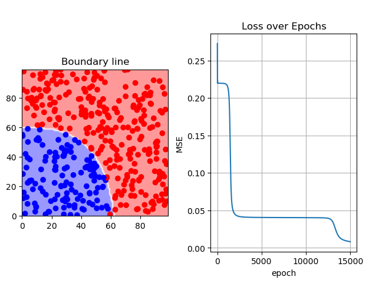

```python
# gradient decent

epochs = 15000
train_size = -1
losses = []

# Construct model
layers = []
for i in range(len(layer_n)-1):
    layers.append(nn.Linear(layer_n[i], layer_n[i+1]))
    layers.append(nn.Sigmoid())

net = nn.Sequential(*layers)
criterion = nn.MSELoss()
opt = th.optim.SGD(net.parameters(), lr=0.1, momentum=0.9)

# Gradient descent
for epoch in range(epochs):

    opt.zero_grad()

    outputs = net(X[:train_size])
    loss = criterion(outputs, Y[:train_size])
    loss.backward()
    opt.step()

    # log loss
    losses.append(loss.item())

# Plot boundary line and loss
heat, pred = get_heatmap(net)
fig = plt.figure()
plot_boundary_loss(fig, heat, losses, title="MLP with Sigmoid functions")
plt.show()
```

#### Stochastic Gradient Decent (SGD)

[Stochastic gradient decent](https://en.wikipedia.org/wiki/Stochastic_gradient_descent) attempts to mitigate some drawbacks of gradient decent. The idea is to replace the gradient in gradient decent with a rough estimation of the gradient which should introduce enough noise that allows the model to escape local minimums.

$$P_{i+1} = P_{i} - \gamma \frac{\partial f_{loss, b}}{\partial P_{i}}$$

where $f_{loss, b}$ is the loss of a subset of the observable data $\tilde{X} \subset X$. The plot below showcases an instance in which the model does not get stuck in a local minimum due to the noisy approximated gradient.

Variations of gradient decent and stochastic gradient decent exists. One of such methods is SGD with momentum

$$P_{i+1} = P_{i} - \gamma \frac{\partial f_{loss, b}}{\partial P_{i}} + \alpha \Delta P_{i}$$

where $\Delta P_{i} = P_{i} - P_{i-1}$ and $0 < \alpha \leq 1$ is a decaying factor that adjusts the contribution of the previous step size on the new one.

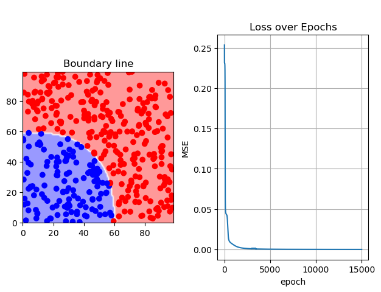

```python
# Storchastic gradient descent

epochs = 15000
train_size = -1
batch_size = 30
losses = []
n_data = X.size(0)

# Construct model
layers = []
for i in range(len(layer_n)-1):
    layers.append(nn.Linear(layer_n[i], layer_n[i+1]))
    layers.append(nn.Sigmoid())

net = nn.Sequential(*layers)
criterion = nn.MSELoss()
opt = th.optim.SGD(net.parameters(), lr=0.1, momentum=0.9)

data_index = th.randperm(n_data) #get random permutation of data

# Storchastic Gradient descent
for epoch in range(epochs):

    lossv = 0.0
    for i in range(0, n_data, batch_size):
        opt.zero_grad()

        outputs = net(X[data_index[i:min(i+batch_size, n_data)]])
        loss = criterion(outputs, Y[data_index[i:min(i+batch_size, n_data)]])
        loss.backward()
        opt.step()

        lossv += loss.item()

    # log loss
    losses.append(lossv/(n_data/batch_size))

# Plot boundary line and loss
heat, pred = get_heatmap(net)
fig = plt.figure()
plot_boundary_loss(fig, heat, losses, title="MLP with Sigmoid functions")
plt.show()
```

### Contributions

To contribute to this page and/or suggest edits, feel free to visit https://github.com/JosueCom/Intro-to-NN.